# Depression in Dane County Highschoolers

Robert George, Varsha Bhandari, and Maya Blitz

## Introduction

“Suicide is the second leading cause of death in young people aged 15–24 years” (The American College of Obstetricians and Gynecologists, 2017).

Many teens around the world struggle with mental illnesses and the stigmas associated with them. We, as data scientists, have all been personally affected by this issue, and seek to dive deeper into mental illness in teens and trends in not seeking treatment for such illnesses.

Using self-reported data from 9th-12th graders in Dane County, Wisconsin, we hope to build a model that uses a variety of childhood factors, mainly dealing with exercise, neighborhood environment, and other factors of interest, to predict whether or not a highschooler in Dane county suffers from clinical depression. We will also consider the influence of demographics on survey response about their experience with long-term depression. The response variable our model will predict is a binary variable, where a response of 0 represents no self-reported long-term depression, and a response of 1 represents self-reported depression. Because there are many missing values in this response variable and throughout the data, we will also explore the correlation between demographics and whether or not each respondent answered the depression question. Hopefully we will be able to uncover a pattern between demographics and whether or not respondents answer the question, trends in clusters of our respondent data, and what factors are most indicative of long-term depression in teens.

## Data

Our data is from the 2018 Dane County Youth Assessment (https://danecountyhumanservices.org/yth/yth_asmt_2018.aspx). This data measures a variety of self-reported demographics of Dane County children from 9th through 12th grade in 2018. These demographics include age, race, and sexual orientation, as well as things like participation in after school programs, family finances, and mental health.

Each row contains 280 columns (it’s quite an exhaustive survey), where each row is a student and each column holds the values of their responses to a variety of questions.

We narrowed down the columns to questions relating to demographics (race and gender identification), neighborhood environment (living situation, parent and family relations, and neighborhood factors), physical health (BMI and exercise), and some confounding factors (depression indicators and how they deal with self-care). Most of the questions have a corresponding number as a response, where the number matches up with a multiple-choice response on the survey. We often cleaned this data by replacing the numbered responses in the data with their corresponding response from the survey. Because of this, most of the variables are categorical and not numerical.

**We narrowed down the data to roughly 35 predictors:**

RespondentID: respondent’s unique ID

Race: respondent’s race

GenderID: respondent’s gender ID

LivingSituation: where do they live (with parents, relatives, foster home, etc)

RunAway: have they ever run away from home

Homeless: have they ever been homeless

ChangedSchools: have they ever changed schools

PhysicallyActive: how many days of the week they are physically active for 60 min or more

NoLimits: 1 if nothing limits them from exercising, 0 if something does

NoTime: 1 if time limits them from exercising, 0 if not

DontLike: 1 if not liking exercising keeps them from exercising, 0 if not

HealthProbs: 1 if health problems keep them from exercising, 0 if not

NoSkills: 1 if lack of skills keep them from exercising, 0 if not

NoProgram: 1 if lack of exercise programs keeps them from exercising, 0 if not

NoSignUp: 1 if not knowing how to sign up for exercise programs keeps them from exercising, 0 if not

CostsTooMuch: 1 if cost keeps them from exercising, 0 if not

NoTransport: 1 if lack of transportation keeps them from exercising, 0 if not

NoExercise_Other: 1 if there is some other unlisted reason that keeps them from exercising, 0 if not

Sleep: on average, how many school nights a week they are awake past past 11pm

DoAboutWeight: what are they trying to do about their weight

FamilyMeals: on an average week, how many days a week they eat meals with their family

ParentMentalHealth: does their parent have a mental health problem that worries them

OKtoGetMentalHealthCare: do they think most youth think it’s okay to get professional help for a mental health issue

CareINeed: do they give themselves the care they need when they are going through a tough time

Depression: the past 12 months have they ever felt sad or hopeless every day for at least 2 weeks such that it keeps them from usual activities

AskNeighborsForHelp: can they ask their neighbor for help

WouldMissNeighborhood: if they had to move, they would miss their neighborhood

SafeInNeighborhood: they feel safe in their neighborhood

NeighborsFriendly: their neighbors are friendly to them

CountOnPolice: they can count on the police if they need them

HelpMyNeighbors: they help their neighbors

AdultsIRelyOn: how many adults, other than their parents, they can rely on

**Along with our response variable:**

DepressionRecode: 1 for having suffered from long-term depression (at least 6 months), 0 for not

## Methods

First, we look at predicting responses and nonreponses in our response variable, with race and gender identification as predictors. It’s important to note that we first do this with nonresponses to race and gender identification included, and as noted earlier, using nonresponses to predict a nonresponse isn’t necessarily showing us something novel. We then seek to do the same but with the nonresponses in race and gender identification removed in order to see the differences in these two models and their accuracies.

Next, we perform a train/test split on our dataset, and generate a decision tree on our training data to predict the probabilities of binary response of a 0 or 1 to our depression response variable based on a handful of our predictors. This tree shows some of the more important predictors of depression in our data, and how the responses to predictors correlate to our response variable. We run our testing data through our new algorithm, and generate a confusion matrix in order to assess the generalizability and accuracy of our model.

Finally, we can also see some of the most important factors in predicting our response variable with a variance importance graph, using a random forest. This graph reflects what variables are chosen most often for branch splits in the decision trees created by our random forest, and all of the variables in our original classification tree are present. This further shows which factors have the most weight in predicting our response variable.

## Results

**Predicting Non-Responses by Demographics**

*Table 1*

```
##
## Call:
## glm(formula = response_binary ~ Race + GenderID, family = "binomial",
##     subset = train_ind)
##
## Deviance Residuals:
##     Min       1Q   Median       3Q      Max
## -1.9759  -1.3808   0.7568   0.7851   2.3239
##
## Coefficients:
##                                                       Estimate Std. Error
## (Intercept)                                            1.35331    0.10951
## RaceBlack or African American (not Hispanic)          -0.88695    0.13440
## RaceHispanic or Latino                                -0.54033    0.12911
## RaceHmong                                              0.25366    0.21883
## RaceMiddle Eastern or North African                   -0.55375    0.31071
## RaceMulti-racial (more than one race)                 -0.69414    0.12757
## RaceNative American/American Indian or Alaskan Native -0.80403    0.24906
## RaceNative Hawaiian or Pacific Islander               -0.55291    0.38253
## RaceNo Info                                           -1.20086    0.22241
## RaceWhite (not Hispanic)                              -0.24942    0.11049
## GenderIDGender Fluid                                  -0.15726    0.21564
## GenderIDMale                                          -0.08478    0.04173
## GenderIDNo Info                                       -2.78312    0.25094
## GenderIDNon-binary                                     0.19196    0.21928
## GenderIDOther                                         -0.42842    0.21266
##                                                       z value Pr(>|z|)
## (Intercept)                                            12.358  < 2e-16 ***
## RaceBlack or African American (not Hispanic)           -6.599 4.13e-11 ***
## RaceHispanic or Latino                                 -4.185 2.85e-05 ***
## RaceHmong                                               1.159  0.24637
## RaceMiddle Eastern or North African                    -1.782  0.07472 .
## RaceMulti-racial (more than one race)                  -5.441 5.29e-08 ***
## RaceNative American/American Indian or Alaskan Native  -3.228  0.00125 **
## RaceNative Hawaiian or Pacific Islander                -1.445  0.14834
## RaceNo Info                                            -5.399 6.69e-08 ***
## RaceWhite (not Hispanic)                               -2.258  0.02398 *
## GenderIDGender Fluid                                   -0.729  0.46584
## GenderIDMale                                           -2.032  0.04219 *
## GenderIDNo Info                                       -11.091  < 2e-16 ***
## GenderIDNon-binary                                      0.875  0.38136
## GenderIDOther                                          -2.015  0.04395 *
## ---
## Signif. codes:  0 '***' 0.001 '**' 0.01 '*' 0.05 '.' 0.1 ' ' 1
##
## (Dispersion parameter for binomial family taken to be 1)
##
##     Null deviance: 14669  on 12215  degrees of freedom
## Residual deviance: 14130  on 12201  degrees of freedom
## AIC: 14160
##
## Number of Fisher Scoring iterations: 4
```

*Table 2*

```
##
## glm.pred    0    1
##        0   63    9
##        1 1141 2860
```

```
## [1] 0.7176528
```

*Table 3*

```
##
## Call:
## glm(formula = response_binary ~ Race + GenderID, family = "binomial",
##     data = cleaned_data_dropNA, subset = train_ind)
##
## Deviance Residuals:
##     Min       1Q   Median       3Q      Max
## -2.0191  -1.4161   0.7619   0.7982   1.1796
##
## Coefficients:
##                                                       Estimate Std. Error
## (Intercept)                                            1.37963    0.10923
## RaceBlack or African American (not Hispanic)          -0.85056    0.13513
## RaceHispanic or Latino                                -0.52888    0.12951
## RaceHmong                                              0.34247    0.22943
## RaceMiddle Eastern or North African                   -0.53120    0.29698
## RaceMulti-racial (more than one race)                 -0.72604    0.12702
## RaceNative American/American Indian or Alaskan Native -0.86175    0.23434
## RaceNative Hawaiian or Pacific Islander               -0.36247    0.37230
## RaceNo Info                                           -0.65003    0.24641
## RaceWhite (not Hispanic)                              -0.29128    0.11013
## GenderIDGender Fluid                                  -0.12547    0.21307
## GenderIDMale                                          -0.10802    0.04163
## GenderIDNon-binary                                     0.17679    0.21526
## GenderIDOther                                         -0.52306    0.21444
##                                                       z value Pr(>|z|)
## (Intercept)                                            12.630  < 2e-16 ***
## RaceBlack or African American (not Hispanic)           -6.294 3.09e-10 ***
## RaceHispanic or Latino                                 -4.084 4.43e-05 ***
## RaceHmong                                               1.493 0.135515
## RaceMiddle Eastern or North African                    -1.789 0.073664 .
## RaceMulti-racial (more than one race)                  -5.716 1.09e-08 ***
## RaceNative American/American Indian or Alaskan Native  -3.677 0.000236 ***
## RaceNative Hawaiian or Pacific Islander                -0.974 0.330259
## RaceNo Info                                            -2.638 0.008340 **
## RaceWhite (not Hispanic)                               -2.645 0.008172 **
## GenderIDGender Fluid                                   -0.589 0.555941
## GenderIDMale                                           -2.595 0.009463 **
## GenderIDNon-binary                                      0.821 0.411490
## GenderIDOther                                          -2.439 0.014721 *
## ---
## Signif. codes:  0 '***' 0.001 '**' 0.01 '*' 0.05 '.' 0.1 ' ' 1
##
## (Dispersion parameter for binomial family taken to be 1)
##
##     Null deviance: 14181  on 11992  degrees of freedom
## Residual deviance: 14058  on 11979  degrees of freedom
## AIC: 14086
##
## Number of Fisher Scoring iterations: 4
```

*Table 4*

```
##
## glm.pred    0    1
##        0  337  605
##        1  782 2274
```

```
## [1] 0.6530765
```

**Clustering**

*Figure 1*

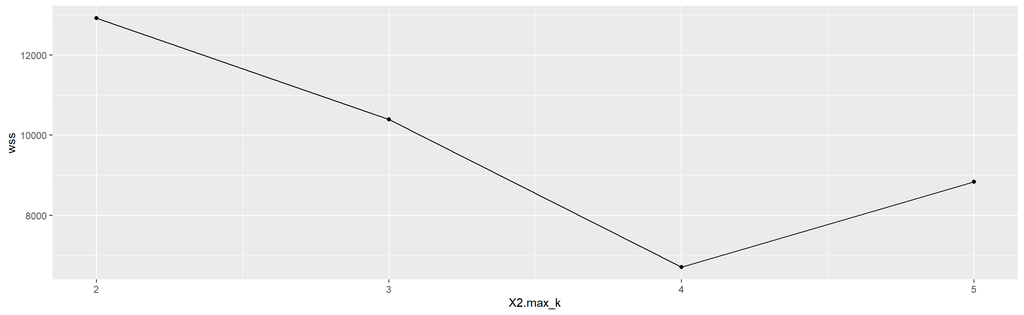

*Figure 2*

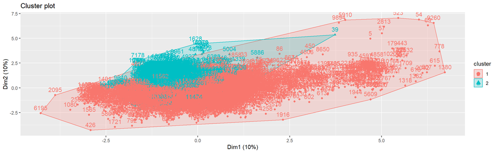

*Table 5*

```
## # A tibble: 2 x 4
##   cluster prop_no_parent_problem prop_care prop_no_depression
##     <int>                  <dbl>     <dbl>              <dbl>
## 1       1                  0.831     0.209              0.686
## 2       2                  0.933     0.419              0.853
```

**Classification Tree**

*Figure 3*

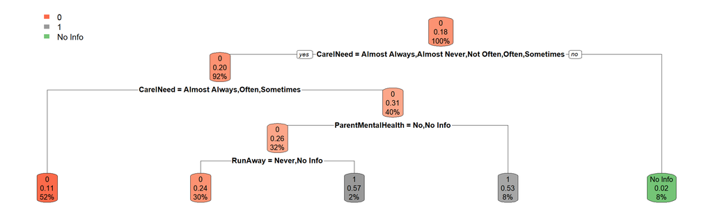

**Assessing Our Tree**

*Table 6*

```
## Confusion Matrix and Statistics
##
##           Reference
## Prediction    0    1 No Info
##    0       1993  536     726
##    1         79  248      88
##    No Info   16    7     305
##
## Overall Statistics
##
##                Accuracy : 0.6368
##                  95% CI : (0.6217, 0.6517)
##     No Information Rate : 0.5223
##     P-Value [Acc > NIR] : < 2.2e-16
##
##                   Kappa : 0.3164
##
##  Mcnemar's Test P-Value : < 2.2e-16
##
## Statistics by Class:
##
##                      Class: 0 Class: 1 Class: No Info
## Sensitivity            0.9545  0.31353        0.27256
## Specificity            0.3393  0.94793        0.99201
## Pos Pred Value         0.6123  0.59759        0.92988
## Neg Pred Value         0.8721  0.84845        0.77820
## Prevalence             0.5223  0.19785        0.27989
## Detection Rate         0.4985  0.06203        0.07629
## Detection Prevalence   0.8142  0.10380        0.08204
## Balanced Accuracy      0.6469  0.63073        0.63229
```

**Random Forest**

*Figure 4: Variable Importance Plot*

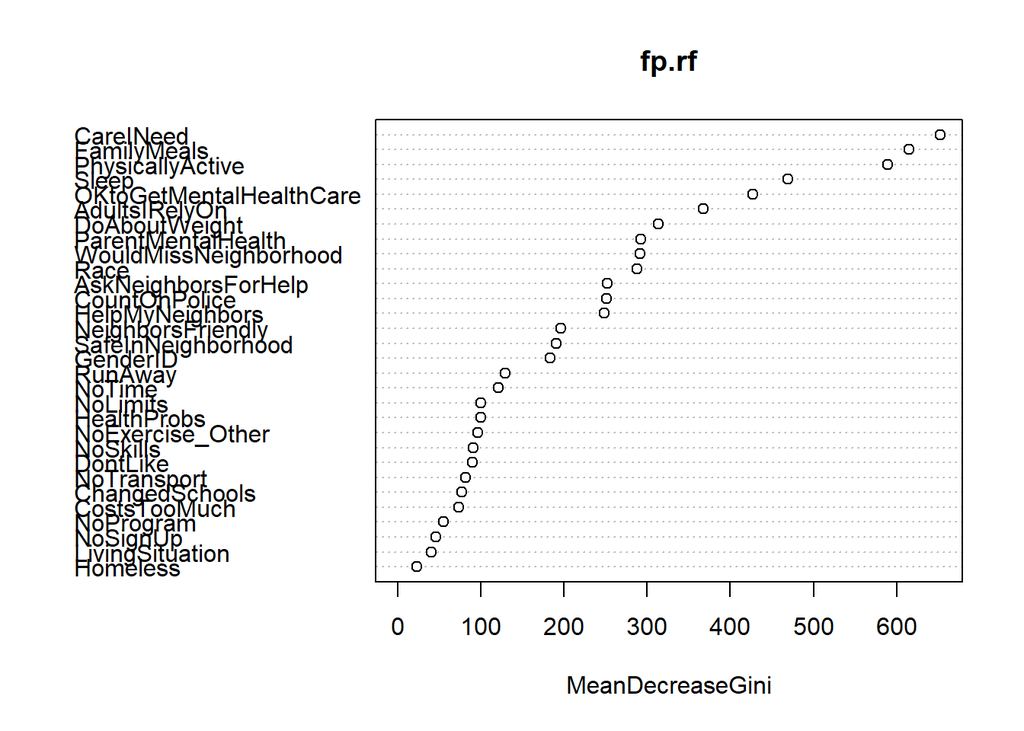

## Interpretation

Figure 4 shows the relative importance of each of our variables in the forking process. CareINeed is the most frequently used variable for forking in the many trees that the random forest creates. This indicates the variable’s importance in predicting depression in our dataset.

## Conclusion

In conclusion, there are a variety of childhood factors that can help us predict whether or not a high schooler in Dane county suffers from clinical depression. Throughout the data shown in the results section, we can assess certain factors of our data that can correlate with depression. However, we want to assert that these variables are not necessarily causal. The mere fact that someone may exhibit responses that we use to predict depression does not mean that they have clinical depression. We are just seeing the correlation between childhood factors and depression.

In predicting non-responses by demographics, we see that there is a higher chance of correctly predicting whether or not a person has depression if information of race and gender were given, because we cannot predict depression if the response variable is missing. Cluster 2 reported a lower proportion of depression and a higher proportion of self-care than Cluster 1, which had higher rates of depression and lower rates of self-care. This result is consistent with our later supervised endeavors, which indicated that self-care is the most influential variable on depression. Figure 4 also shows that factors like self-care, eating meals with family, physical activity and sleep are important factors in determining whether or not a student is diagnosed with depression. Ultimately, we see that there is an obvious and significant correlation between depression in high-schoolers and general self-care. Physical activity, sleep, and self-care are all highly predictive of depression in our data. Interestingly, activities that promote family wellbeing like eating with your family also had a strong effect on depression.

One of the main limitations with our project is the fact that were a lot of nonresponses in the data. This hindered our process of making a model and the accuracy of our model in predicting our response variable. The more data with responses, the better our accuracy of predicting our response variable would have been. Additionally, we could have explored more predictors in the Dane County Youth Assessment dataset, like the different school activities and predictors related to their school life to explore how different factors of school can affect a student’s mental health. Future research with this data might be concerned with further illuminating trends in nonresponse, to see how robust our ability to predict depression actually is with this data. It is in the opinion of the authors that the survey may not represent the true extent of depression in Dane County Highschoolers.